# Tarea GLM

Armando Olivares

8 de febrero de 2018

El set de datos windscreen.csv que se proporciona contiene datos ﬁcticios relativos al año 2011 de una aseguradora de automóviles. Concretamente, se trata de una tabla donde cada observación corresponde a un asegurado, donde tienes información propia del asegurado (edad, ciudad, tipo de coche, etc.), el coste total por siniestros relativos a las lunas de su coche (INCURR_COST), el número de siniestros de este tipo que ha sufrido (N_CLAIMS) y su exposición (EXPOSURE), es decir, la fracción del año que el sujeto ha estado asegurado.

```r
suppressWarnings(suppressMessages(library(tidyverse)))
suppressWarnings(suppressMessages(library(caret)))
suppressWarnings(suppressMessages(library(insuranceData)))
suppressWarnings(suppressMessages(library(fitdistrplus)))
suppressWarnings(suppressMessages(library(mice)))
suppressWarnings(suppressMessages(library(VIM)))
suppressWarnings(suppressMessages(library(modeest)))
suppressWarnings(suppressMessages(library(ggplot2)))
```

### Cargamos Nuestros Datos

```r
windscren <- read.csv("windscreen.csv", sep = ";", na.strings = "")
set.seed(4)
```

### Análisis Preliminar

```r
str(windscren)
```

```
## 'data.frame':    24919 obs. of  22 variables:
##  $ YEAR          : int  2011 2011 2011 2011 2011 2011 2011 2011 2011 2011 ...
##  $ EARNED_PREMIUM: num  15.04 16.07 5.74 21.43 16.22 ...
##  $ INSTALLMENT   : int  2 2 1 1 2 1 1 1 1 1 ...
##  $ GENDER        : int  1 1 1 1 1 1 1 1 1 1 ...
##  $ AGE_DRIVER    : int  44 24 51 59 47 61 54 38 50 33 ...
##  $ AGE_LICENSE   : int  17 3 18 40 25 42 35 20 14 9 ...
##  $ AGE_ADD_DRIVER: int  9999 9999 9999 9999 9999 9999 9999 9999 9999 9999 ...
##  $ AGE_VEHICLE   : int  10 5 1 9 4 6 5 10 14 4 ...
##  $ CITIES        : int  46 50 21 46 8 43 8 8 6 23 ...
##  $ BRAND_TEXT    : Factor w/ 77 levels "ALFA ROMEO","ASIA MOTORS",..: 48 18 18 18 18 18 18 11 61 52 ...
##  $ HPOWER        : int  5 5 8 9 7 7 7 5 4 9 ...
##  $ FUEL          : Factor w/ 5 levels "D","E","G","L",..: 1 1 1 1 1 1 1 1 3 1 ...
##  $ VALUE_VEHICLE : num  14875 14910 20400 23170 16420 ...
##  $ POSTCODE      : int  46019 50196 21560 46014 8013 43791 8013 8820 6100 23440 ...
##  $ N_CLAIMS      : int  0 0 0 0 0 0 0 0 0 0 ...
##  $ INCURR_COST   : num  0 0 0 0 0 0 0 0 0 0 ...
##  $ EXPOSURE      : num  0.87 1 0.3 1 1 1 0.04 0.07 0.34 1 ...
##  $ ANTPOL        : int  1 1 1 1 1 1 1 1 1 1 ...
##  $ pesopot       : num  18.8 19.3 15 15.7 16.5 ...
##  $ DES_ZONE2     : Factor w/ 4 levels "añadido","Rural",..: 4 2 2 4 4 2 4 3 2 2 ...
##  $ DES_ZONE      : Factor w/ 13 levels "Capital","Corona",..: 1 2 5 1 1 5 1 2 2 7 ...
##  $ FUEL2         : Factor w/ 2 levels "D","G": 1 1 1 1 1 1 1 1 2 1 ...
```

Notamos que tenemos 24.919 observaciones con 22 Variables, de las cuales 5 están clasificadas como factor y el resto son variables númericas.

```r
summary(windscren)
```

```
##       YEAR      EARNED_PREMIUM      INSTALLMENT        GENDER
##  Min.   :2011   Min.   :  0.0261   Min.   :1.000   Min.   :1.000
##  1st Qu.:2011   1st Qu.: 12.4482   1st Qu.:1.000   1st Qu.:1.000
##  Median :2011   Median : 20.4161   Median :1.000   Median :1.000
##  Mean   :2011   Mean   : 24.0630   Mean   :1.231   Mean   :1.226
##  3rd Qu.:2011   3rd Qu.: 31.4977   3rd Qu.:1.000   3rd Qu.:1.000
##  Max.   :2011   Max.   :589.8043   Max.   :9.000   Max.   :8.000
##
##    AGE_DRIVER       AGE_LICENSE      AGE_ADD_DRIVER  AGE_VEHICLE
##  Min.   :  20.00   Min.   :   1.00   Min.   :  18   Min.   :   0.00
##  1st Qu.:  43.00   1st Qu.:  21.00   1st Qu.:9999   1st Qu.:   7.00
##  Median :  53.00   Median :  30.00   Median :9999   Median :  11.00
##  Mean   :  75.11   Mean   :  49.61   Mean   :8195   Mean   :  16.68
##  3rd Qu.:  62.00   3rd Qu.:  38.00   3rd Qu.:9999   3rd Qu.:  14.00
##  Max.   :9999.00   Max.   :9999.00   Max.   :9999   Max.   :9999.00
##
##      CITIES        BRAND_TEXT        HPOWER       FUEL
##  Min.   : 1.00   RENAULT: 3087   Min.   : 1.000   D:15132
##  1st Qu.:10.00   CITROEN: 2889   1st Qu.: 5.000   E:    1
##  Median :25.00   PEUGEOT: 2402   Median : 7.000   G: 9770
##  Mean   :24.56   FORD   : 2308   Mean   : 6.787   L:    4
##  3rd Qu.:37.00   OPEL   : 2164   3rd Qu.: 8.000   X:   12
##  Max.   :99.00   SEAT   : 2010   Max.   :13.000
##                  (Other):10059
##  VALUE_VEHICLE         POSTCODE        N_CLAIMS        INCURR_COST
##  Min.   :   631.1   Min.   :    0   Min.   :0.00000   Min.   :-191.81
##  1st Qu.: 12500.0   1st Qu.:10145   1st Qu.:0.00000   1st Qu.:   0.00
##  Median : 16300.0   Median :25230   Median :0.00000   Median :   0.00
##  Mean   : 18175.3   Mean   :24929   Mean   :0.04077   Mean   :  11.41
##  3rd Qu.: 21582.5   3rd Qu.:37541   3rd Qu.:0.00000   3rd Qu.:   0.00
##  Max.   :404736.0   Max.   :99999   Max.   :3.00000   Max.   :1021.42
##
##     EXPOSURE          ANTPOL         pesopot         DES_ZONE2
##  Min.   :0.0100   Min.   : 1.00   Min.   :  0.00   añadido:   66
##  1st Qu.:0.5700   1st Qu.: 2.00   1st Qu.: 11.46   Rural  :13924
##  Median :1.0000   Median : 4.00   Median : 13.33   SubUrb : 5345
##  Mean   :0.7862   Mean   : 5.97   Mean   : 13.72   Urbano : 5080
##  3rd Qu.:1.0000   3rd Qu.:10.00   3rd Qu.: 15.60   NA's   :  504
##  Max.   :1.0000   Max.   :14.00   Max.   :999.00
##
##           DES_ZONE    FUEL2
##  Capital      :6229   D:15132
##  Corona       :3397   G: 9787
##  Rural - Tam 5:3003
##  Rural - Tam 2:2753
##  Influencia   :2456
##  (Other)      :7042
##  NA's         :  39
```

Realiza un leve análisis exploratorio del set de datos, para formular las hipótesis que consideres oportunas acerca de la relación entre los costes generados porcada cliente y el resto de variables.

### Primero Observamos la distribucion de NA’s:

```r
# Distribución de NA's

md.pattern(windscren)
```

```
##       YEAR EARNED_PREMIUM INSTALLMENT GENDER AGE_DRIVER AGE_LICENSE
## 24415    1              1           1      1          1           1
##   465    1              1           1      1          1           1
##    39    1              1           1      1          1           1
##          0              0           0      0          0           0
##       AGE_ADD_DRIVER AGE_VEHICLE CITIES BRAND_TEXT HPOWER FUEL
## 24415              1           1      1          1      1    1
##   465              1           1      1          1      1    1
##    39              1           1      1          1      1    1
##                    0           0      0          0      0    0
##       VALUE_VEHICLE POSTCODE N_CLAIMS INCURR_COST EXPOSURE ANTPOL pesopot
## 24415             1        1        1           1        1      1       1
##   465             1        1        1           1        1      1       1
##    39             1        1        1           1        1      1       1
##                   0        0        0           0        0      0       0
##       FUEL2 DES_ZONE DES_ZONE2
## 24415     1        1         1   0
##   465     1        1         0   1
##    39     1        0         0   2
##           0       39       504 543
```

```r
sapply(windscren, function(x) sum(is.na(x)))
```

```
##           YEAR EARNED_PREMIUM    INSTALLMENT         GENDER     AGE_DRIVER
##              0              0              0              0              0
##    AGE_LICENSE AGE_ADD_DRIVER    AGE_VEHICLE         CITIES     BRAND_TEXT
##              0              0              0              0              0
##         HPOWER           FUEL  VALUE_VEHICLE       POSTCODE       N_CLAIMS
##              0              0              0              0              0
##    INCURR_COST       EXPOSURE         ANTPOL        pesopot      DES_ZONE2
##              0              0              0              0            504
##       DES_ZONE          FUEL2
##             39              0
```

Imputaremos a la moda las observaciones que tengan NA

```r
windscren$DES_ZONE2[is.na(windscren$DES_ZONE2)] <- "Rural"
windscren$DES_ZONE[is.na(windscren$DES_ZONE)] <- "Capital"
windscren$GENDER[(windscren$GENDER == 8)] <- 1
windscren$AGE_DRIVER[(windscren$AGE_DRIVER == 9999)] <- unique(windscren$AGE_DRIVER)[which.max(tabulate(match(windscren$AGE_DRIVER, unique(windscren$AGE_DRIVER))))]
windscren$AGE_LICENSE[(windscren$AGE_LICENSE == 9999)] <- unique(windscren$AGE_LICENSE)[which.max(tabulate(match(windscren$AGE_LICENSE, unique(windscren$AGE_LICENSE))))]

windscren$AGE_VEHICLE[(windscren$AGE_VEHICLE == 9999)] <- unique(windscren$AGE_VEHICLE)[which.max(tabulate(match(windscren$AGE_VEHICLE, unique(windscren$AGE_VEHICLE))))]
windscren$AGE_ADD_DRIVER[(windscren$AGE_ADD_DRIVER == 9999)] <- unique(windscren$AGE_ADD_DRIVER)[which.max(tabulate(match(windscren$AGE_ADD_DRIVER, unique(windscren$AGE_ADD_DRIVER))))]
```

```r
summary(windscren)
```

```
##       YEAR      EARNED_PREMIUM      INSTALLMENT        GENDER
##  Min.   :2011   Min.   :  0.0261   Min.   :1.000   Min.   :1.000
##  1st Qu.:2011   1st Qu.: 12.4482   1st Qu.:1.000   1st Qu.:1.000
##  Median :2011   Median : 20.4161   Median :1.000   Median :1.000
##  Mean   :2011   Mean   : 24.0630   Mean   :1.231   Mean   :1.212
##  3rd Qu.:2011   3rd Qu.: 31.4977   3rd Qu.:1.000   3rd Qu.:1.000
##  Max.   :2011   Max.   :589.8043   Max.   :9.000   Max.   :2.000
##
##    AGE_DRIVER     AGE_LICENSE    AGE_ADD_DRIVER  AGE_VEHICLE
##  Min.   :20.00   Min.   : 1.00   Min.   :  18   Min.   : 0.00
##  1st Qu.:43.00   1st Qu.:21.00   1st Qu.:9999   1st Qu.: 7.00
##  Median :53.00   Median :30.00   Median :9999   Median :11.00
##  Mean   :53.15   Mean   :29.21   Mean   :8195   Mean   :11.07
##  3rd Qu.:62.00   3rd Qu.:38.00   3rd Qu.:9999   3rd Qu.:14.00
##  Max.   :96.00   Max.   :72.00   Max.   :9999   Max.   :58.00
##
##      CITIES        BRAND_TEXT        HPOWER       FUEL
##  Min.   : 1.00   RENAULT: 3087   Min.   : 1.000   D:15132
##  1st Qu.:10.00   CITROEN: 2889   1st Qu.: 5.000   E:    1
##  Median :25.00   PEUGEOT: 2402   Median : 7.000   G: 9770
##  Mean   :24.56   FORD   : 2308   Mean   : 6.787   L:    4
##  3rd Qu.:37.00   OPEL   : 2164   3rd Qu.: 8.000   X:   12
##  Max.   :99.00   SEAT   : 2010   Max.   :13.000
##                  (Other):10059
##  VALUE_VEHICLE         POSTCODE        N_CLAIMS        INCURR_COST
##  Min.   :   631.1   Min.   :    0   Min.   :0.00000   Min.   :-191.81
##  1st Qu.: 12500.0   1st Qu.:10145   1st Qu.:0.00000   1st Qu.:   0.00
##  Median : 16300.0   Median :25230   Median :0.00000   Median :   0.00
##  Mean   : 18175.3   Mean   :24929   Mean   :0.04077   Mean   :  11.41
##  3rd Qu.: 21582.5   3rd Qu.:37541   3rd Qu.:0.00000   3rd Qu.:   0.00
##  Max.   :404736.0   Max.   :99999   Max.   :3.00000   Max.   :1021.42
##
##     EXPOSURE          ANTPOL         pesopot         DES_ZONE2
##  Min.   :0.0100   Min.   : 1.00   Min.   :  0.00   añadido:   66
##  1st Qu.:0.5700   1st Qu.: 2.00   1st Qu.: 11.46   Rural  :14428
##  Median :1.0000   Median : 4.00   Median : 13.33   SubUrb : 5345
##  Mean   :0.7862   Mean   : 5.97   Mean   : 13.72   Urbano : 5080
##  3rd Qu.:1.0000   3rd Qu.:10.00   3rd Qu.: 15.60
##  Max.   :1.0000   Max.   :14.00   Max.   :999.00
##
##           DES_ZONE    FUEL2
##  Capital      :6268   D:15132
##  Corona       :3397   G: 9787
##  Rural - Tam 5:3003
##  Rural - Tam 2:2753
##  Influencia   :2456
##  Rural - Tam 4:2394
##  (Other)      :4648
```

### Examinaremos La Distribución de las variables:

Para la Variable ** N_claims **:

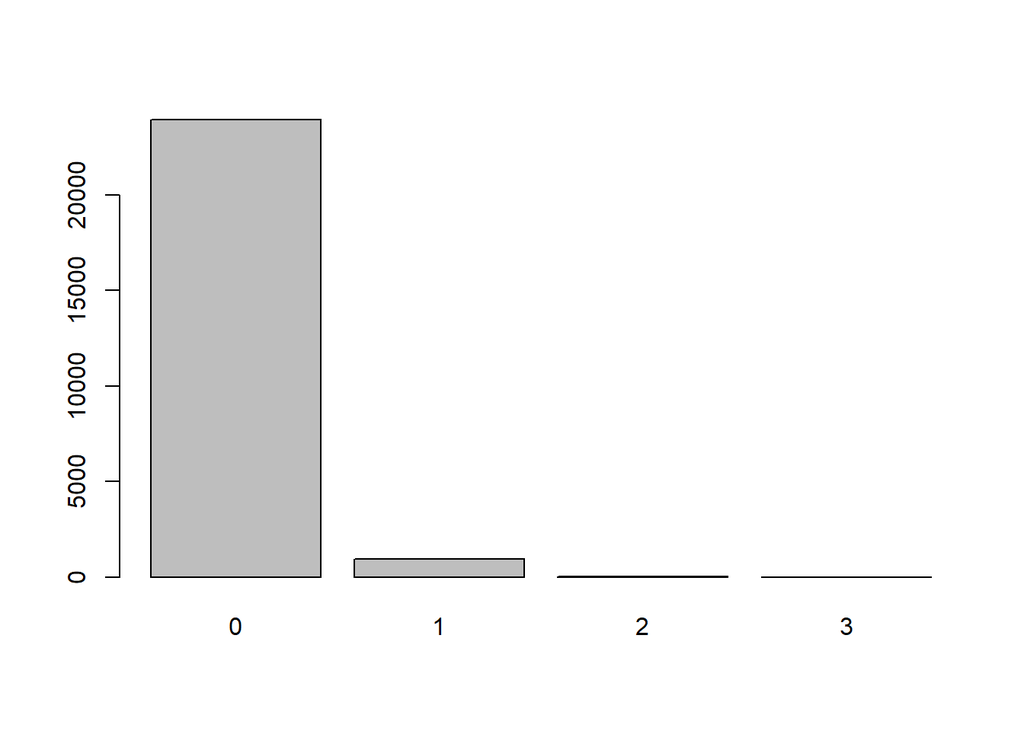

```r
barplot((table(windscren$N_CLAIMS)))
```

Es díficil de interpretar por lo que tomaremos el ** log de las observaciones **:

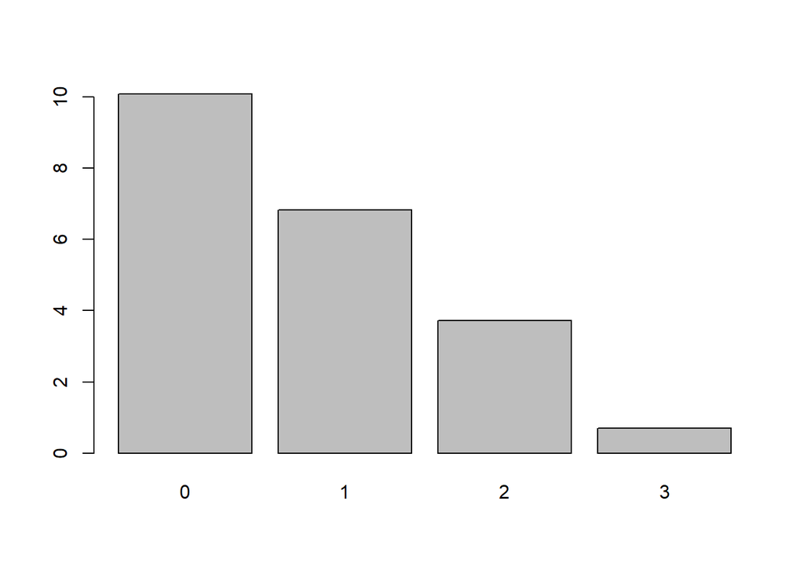

```r
barplot(log(table(windscren$N_CLAIMS)))
```

De lo que extraemos que el número de reclamos para el año 2011, vas desde 0-3.

Para la Variable ** Gender **:

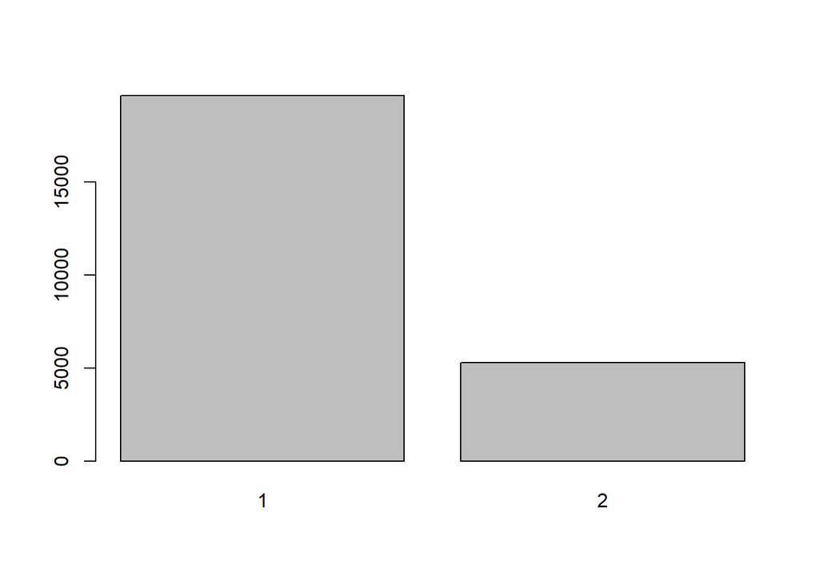

```r
barplot(table(windscren$GENDER))
```

Para la Variable ** Dess_zone 2 **:

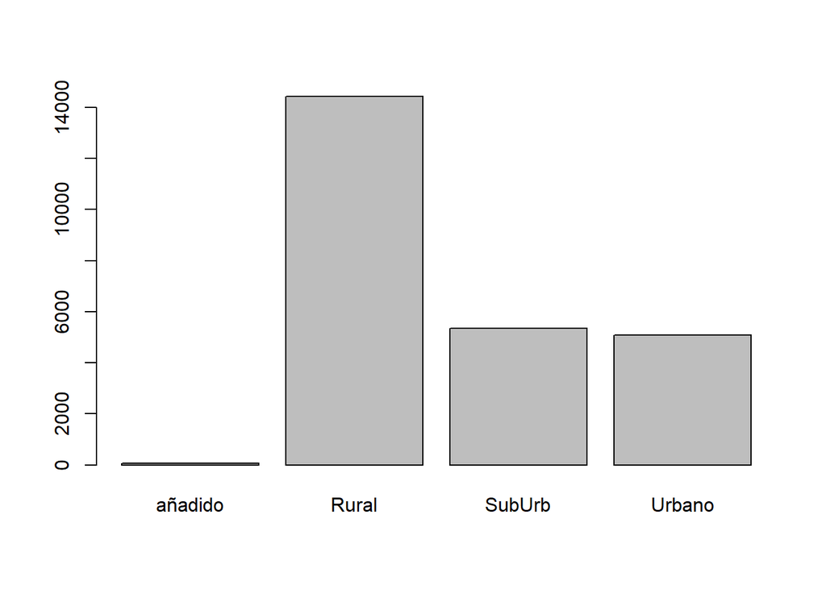

```r
barplot(table(windscren$DES_ZONE2))
```

Para las Variables Continuas, graficaremos las densidades:

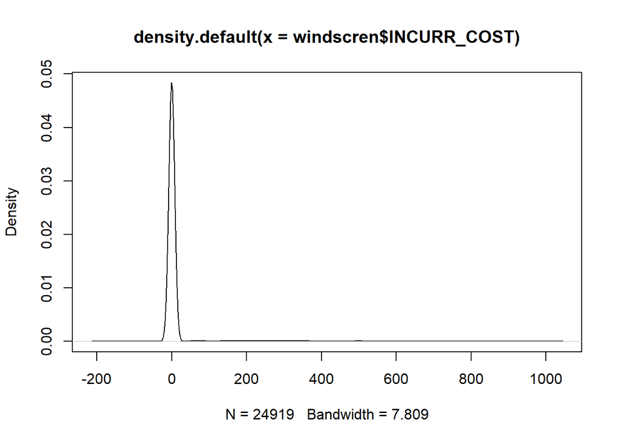

```r
plot(density(windscren$INCURR_COST))
```

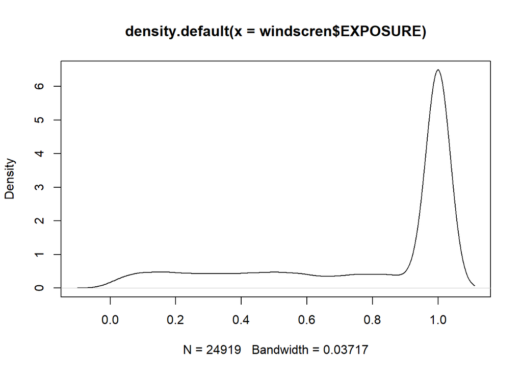

```r
plot(density(windscren$EXPOSURE))
```

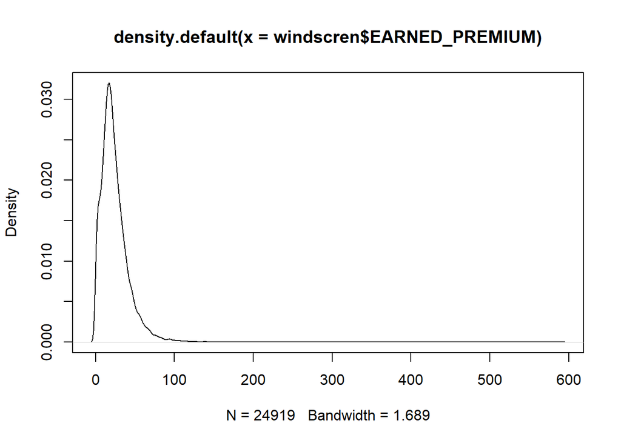

```r
plot(density(windscren$EARNED_PREMIUM))
```

Trataremos de establecer una relación entre los costes generados por cada cliente y el resto de variables

partimos del hecho que a mayor número de siniestro mayor es el coste generado a la aseguradora.

Primero la variable **Incurred_cost vs Age_driver**

Para ello creamos una **nueva** variable a fin de analizar por **intervalos de edad**

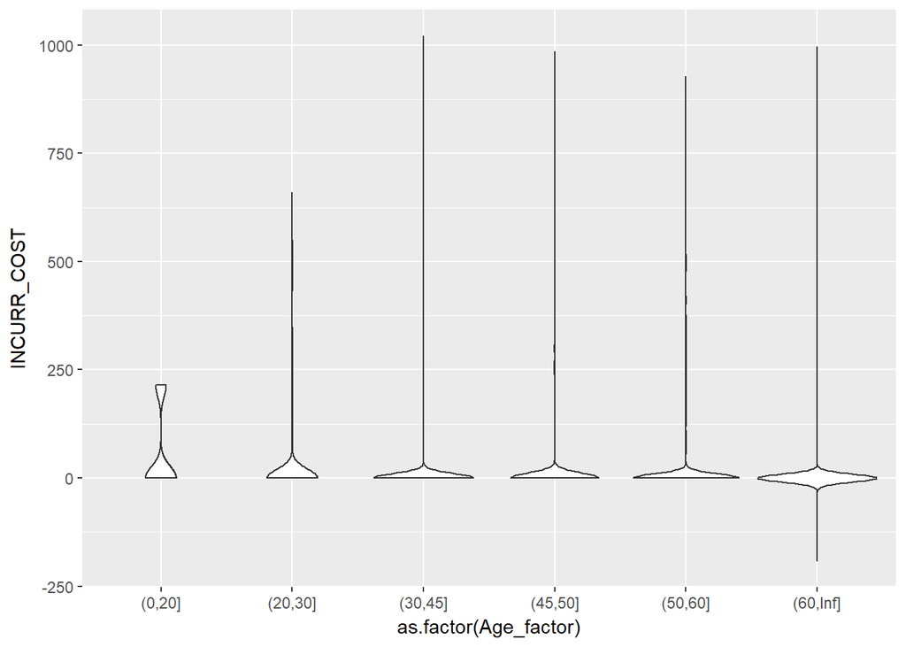

```r
windscren$Age_factor <-  cut(windscren$AGE_DRIVER, breaks=c(0, 20, 30,45, 50, 60, Inf),  sep="")

ggplot(windscren, aes(x=as.factor(Age_factor), y=INCURR_COST)) +
  geom_violin()
```

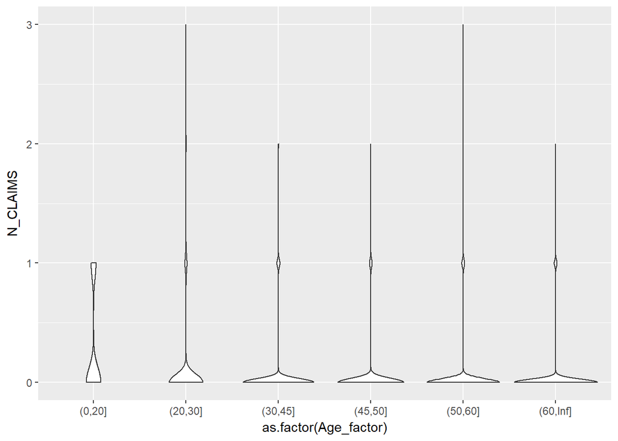

```r
ggplot(windscren, aes(x=as.factor(Age_factor), y=N_CLAIMS)) +
  geom_violin()
```

```r
table(windscren$N_CLAIMS, windscren$Age_factor)
```

```
##
##     (0,20] (20,30] (30,45] (45,50] (50,60] (60,Inf]
##   0      3     612    6613    3205    6531     6984
##   1      1      36     283     127     250      231
##   2      0       2      14       4      13        8
##   3      0       1       0       0       1        0
```

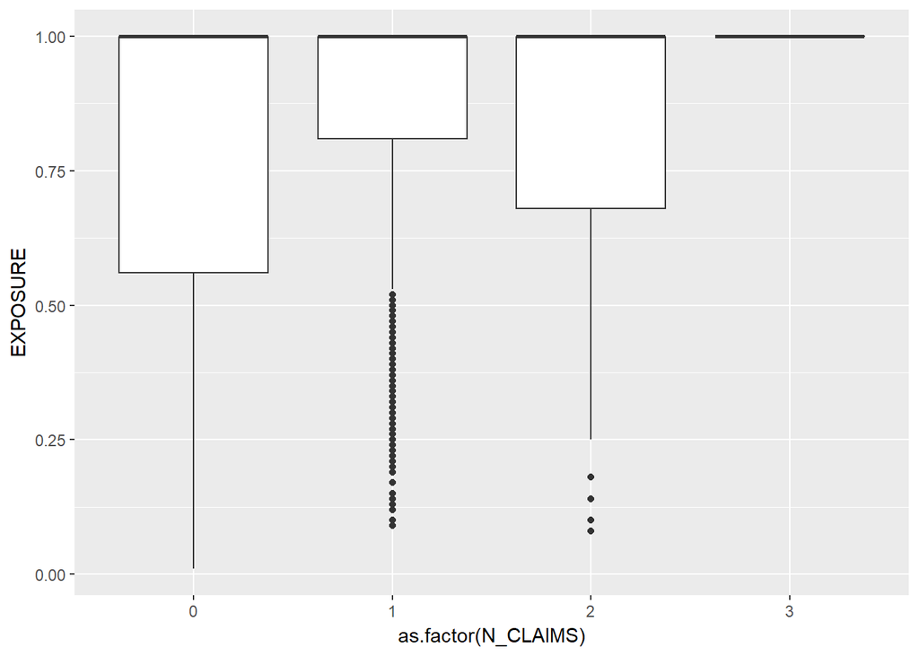

```r
ggplot(windscren, aes(x=as.factor(N_CLAIMS), y=EXPOSURE)) +
  geom_boxplot()
```

**Añadimos** una nueva **variable** para discriminar por intervalo de tiempo que el sujeto ha estado asegurado

```r
windscren$tiempo_fracc <-  cut(windscren$EXPOSURE, breaks=c(0, 0.25, 0.5, 0.75, Inf),  sep="")
table(windscren$N_CLAIMS, windscren$tiempo_fracc)
```

```
##
##     (0,0.25] (0.25,0.5] (0.5,0.75] (0.75,Inf]
##   0     2802       2648       2400      16098
##   1       34         77        102        715
##   2        5          1          8         27
##   3        0          0          0          2
```

** Observamos que la mayoría de los siniestros ocurren en sujetos que han estado asegurado por casi todo el año.**

Revisamos ahora por genero

```r
table(windscren$N_CLAIMS, windscren$GENDER)
```

```
##
##         1     2
##   0 18840  5108
##   1   766   162
##   2    33     8
##   3     2     0
```

Lo sujeto que más han incurrido en siniestros son los del genero 1(¿tal vez hombres?)

Revisamos ahora el costo ó valor del Vehículo

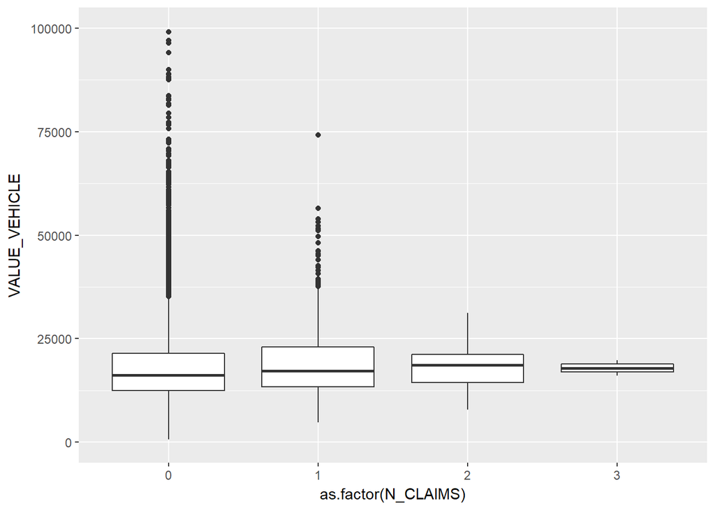

```r
ggplot(windscren, aes(x=as.factor(N_CLAIMS), y=VALUE_VEHICLE)) +
  geom_boxplot()+ scale_y_continuous(limits = c(-1, 1e5))
```

En promedio **no** parece haber mucha diferencia entre el valor del coche y número de accidentes, aunque claramente si el valor del coche es alto también lo será el costo generado a la empresa por razones obvias.

Revisamos ahora la fuerza del vehículo, expresado en HP

```r
table(windscren$N_CLAIMS, windscren$HPOWER)
```

```
##
##        1    2    3    4    5    6    7    8    9   10   11   12   13
##   0  123  152  336 2645 4514 1841 6688 2950 2701  840  633  210  315
##   1    2    4    5   83  177   77  241  131  122   34   32    8   12
##   2    0    0    0    2    4    3   16    9    5    2    0    0    0
##   3    0    0    0    0    0    0    2    0    0    0    0    0    0
```

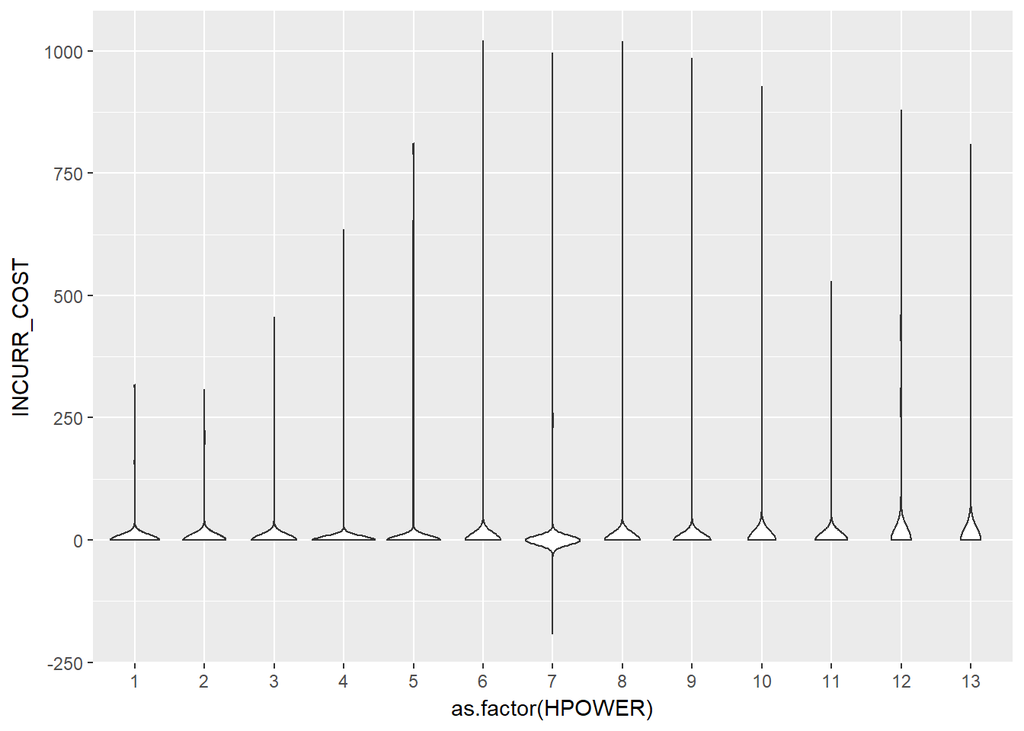

```r
ggplot(windscren, aes(x=as.factor(HPOWER), y=INCURR_COST)) +
  geom_violin()
```

Se observa que los coches con HP entre 6-9 son los ocasionan más gasto a la aseguradora.

#### b) Determina la prima pura conservadora desde el punto de vista de la aseguradora

Está se determinará como la media de costo incurrido el año anterior(en este caso el año anterior es el 2011) por lo que:

```r
mean(windscren$INCURR_COST)/mean(windscren$EXPOSURE)
```

```
## [1] 14.51194
```

#### Ajusta (y optimiza) algún modelo más soﬁsticado para determinar la prima pura más justa para cada asegurado, y compara su rendimiento con el que ofrecería esa prima pura conservadora (es decir, determina, de la forma que consideres oportuna, si el modelo que has ajustado es más justo que el más conservador).

** Coste = Número de siniestros × Coste medio por siniestro. **

```r
sum(windscren$INCURR_COST== 0)
```

```
## [1] 23953
```

```r
sum(windscren$N_CLAIMS==0)
```

```
## [1] 23948
```

```r
windscren[windscren$INCURR_COST == 0 & windscren$N_CLAIMS !=0, ]$N_CLAIMS <- 0


intrain<-createDataPartition(y=windscren$YEAR, p=0.8,list=FALSE)
train_windscren<-windscren[intrain,]
test_windscren<-windscren[-intrain,]



train_control<- trainControl(method="cv", number=10, savePredictions = TRUE)




suppressWarnings(model.n_claims <- train(N_CLAIMS/EXPOSURE ~ GENDER + AGE_DRIVER + HPOWER + CITIES+ AGE_LICENSE  ,
                        data = train_windscren,
                        trControl = train_control,
                        method = 'glm',
                        family = poisson(link = 'log'),
                        na.action = na.omit) )

summary(model.n_claims)
```

```
##
## Call:
## NULL
##
## Deviance Residuals:
##     Min       1Q   Median       3Q      Max
## -0.5480  -0.3663  -0.3267  -0.2911  11.6845
##
## Coefficients:
##              Estimate Std. Error z value Pr(>|z|)
## (Intercept) -2.122531   0.212336  -9.996  < 2e-16 ***
## GENDER      -0.435891   0.082145  -5.306 1.12e-07 ***
## AGE_DRIVER  -0.004688   0.004264  -1.099 0.271630
## HPOWER       0.057471   0.014128   4.068 4.75e-05 ***
## CITIES       0.004312   0.001992   2.165 0.030358 *
## AGE_LICENSE -0.017290   0.004711  -3.670 0.000242 ***
## ---
## Signif. codes:  0 '***' 0.001 '**' 0.01 '*' 0.05 '.' 0.1 ' ' 1
##
## (Dispersion parameter for poisson family taken to be 1)
##
##     Null deviance: 7861.7  on 19935  degrees of freedom
## Residual deviance: 7749.3  on 19930  degrees of freedom
## AIC: Inf
##
## Number of Fisher Scoring iterations: 6
```

```r
data_nonzero = train_windscren[train_windscren$INCURR_COST>0, ]
suppressWarnings(model.claimcost <- train(INCURR_COST/N_CLAIMS ~ GENDER + AGE_DRIVER + HPOWER + DES_ZONE +DES_ZONE2,
                         data = data_nonzero,
                         trControl = train_control,
                         method = 'glm',
                         family = Gamma(link = 'log'),
                         weights = EXPOSURE,
                         na.action = na.omit))

summary(model.claimcost)
```

```
##
## Call:
## NULL
##
## Deviance Residuals:
##      Min        1Q    Median        3Q       Max
## -1.98388  -0.36995  -0.05524   0.23716   1.20698
##
## Coefficients: (2 not defined because of singularities)
##                            Estimate Std. Error t value Pr(>|t|)
## (Intercept)                5.340621   0.131883  40.495  < 2e-16 ***
## GENDER                    -0.022865   0.049165  -0.465    0.642
## AGE_DRIVER                -0.001108   0.001483  -0.747    0.455
## HPOWER                     0.050479   0.009082   5.558 3.78e-08 ***
## DES_ZONECorona            -0.005588   0.070480  -0.079    0.937
## DES_ZONEInfluencia        -0.053062   0.071809  -0.739    0.460
## `DES_ZONERural - Tam 1`   -0.003750   0.101097  -0.037    0.970
## `DES_ZONERural - Tam 2`    0.004464   0.083436   0.054    0.957
## `DES_ZONERural - Tam 3`    0.142244   0.092548   1.537    0.125
## `DES_ZONERural - Tam 4`    0.126542   0.085351   1.483    0.139
## `DES_ZONERural - Tam 5`   -0.028477   0.086299  -0.330    0.742
## `DES_ZONERural - Tam 6`   -0.059416   0.096024  -0.619    0.536
## `DES_ZONERural - Tam 7`   -0.080948   0.179832  -0.450    0.653
## `DES_ZONERural - Tam 8`   -0.198568   0.806622  -0.246    0.806
## `DES_ZONERural - Tam 9`          NA         NA      NA       NA
## `DES_ZONERural - Tam 999`  0.271274   0.483235   0.561    0.575
## DES_ZONE2Rural             0.072107   0.069279   1.041    0.298
## DES_ZONE2SubUrb           -0.092308   0.065058  -1.419    0.156
## DES_ZONE2Urbano                  NA         NA      NA       NA
## ---
## Signif. codes:  0 '***' 0.001 '**' 0.01 '*' 0.05 '.' 0.1 ' ' 1
##
## (Dispersion parameter for Gamma family taken to be 0.2267769)
##
##     Null deviance: 219.95  on 775  degrees of freedom
## Residual deviance: 205.94  on 759  degrees of freedom
## AIC: 8537.7
##
## Number of Fisher Scoring iterations: 5
```

### Revisamos con el test de ANOVA si le podemos agregar otra variable al Modelo, por ejemplo **CITIES**

```r
suppressWarnings(model.n_claims2 <- train(N_CLAIMS/EXPOSURE ~ GENDER + AGE_DRIVER + HPOWER + AGE_LICENSE  ,
                        data = train_windscren,
                        trControl = train_control,
                        method = 'glm',
                        family = poisson(link = 'log'),
                        na.action = na.omit) )
anova(model.n_claims2$finalModel, model.n_claims$finalModel, test = "Chisq")
```

```
## Analysis of Deviance Table
##
## Model 1: .outcome ~ GENDER + AGE_DRIVER + HPOWER + AGE_LICENSE
## Model 2: .outcome ~ GENDER + AGE_DRIVER + HPOWER + CITIES + AGE_LICENSE
##   Resid. Df Resid. Dev Df Deviance Pr(>Chi)
## 1     19931     7754.0
## 2     19930     7749.3  1   4.6822  0.03048 *
## ---
## Signif. codes:  0 '***' 0.001 '**' 0.01 '*' 0.05 '.' 0.1 ' ' 1
```

### Con los modelos obtenidos:

Coste = Número de siniestros × Coste medio por siniestro. El número de siniestros se modela mediante un GLM de tipo Poisson. El coste medio por siniestro se modela mediante un GLM de tipo Gamma. La credibilidad que se otorga a cada una de las observaciones se pondera en base a su exposición (la fracción del año que ha transcurrido desde que fue contratada la póliza).

#### Procedemos a Predecir el *N_CLAIMS* y el *INCURR_COST*

```r
n_claim_pred <- predict(model.n_claims2, test_windscren[,c("GENDER", "AGE_DRIVER", "HPOWER", "AGE_LICENSE")])
```

```r
head(test_windscren$N_CLAIMS)
```

```
## [1] 0 0 0 0 0 0
```

```r
head(n_claim_pred)
```

```
##          5         10         16         26         31         35
## 0.06711200 0.10586986 0.03272721 0.07906253 0.05752328 0.05736143
```

```r
mean(n_claim_pred)
```

```
## [1] 0.05733857
```

```r
mean(test_windscren$N_CLAIMS)
```

```
## [1] 0.04093919
```

Para el * INCURR_COST *

```r
cost_pred <- predict(model.claimcost, test_windscren[,c("GENDER", "AGE_DRIVER", "HPOWER", "DES_ZONE", "DES_ZONE2")])
```

Observando las Medias tenemos que:

Para el Modelo:

```r
mean(cost_pred*n_claim_pred)
```

```
## [1] 16.45758
```

Para la Predicción Conservadora:

```r
mean(test_windscren$INCURR_COST)/mean(test_windscren$EXPOSURE)
```

```
## [1] 14.15568
```

### Por último tomaremos el ratio entre la prima predicha y la prima conservadora, a fin de analizar mejor cada individuo:

```r
ratio_primas <- cost_pred*n_claim_pred/(mean(test_windscren$INCURR_COST)/mean(test_windscren$EXPOSURE))
```

```r
test_windscren["ratio"] <- ratio_primas
```

#### Observamos nuestro ajuste

```r
head(test_windscren)
```

```
##    YEAR EARNED_PREMIUM INSTALLMENT GENDER AGE_DRIVER AGE_LICENSE
## 5  2011      16.215815           2      1         47          25
## 10 2011      38.401618           1      1         33           9
## 16 2011      15.269059           1      2         67          36
## 26 2011      25.793409           2      1         43          10
## 31 2011      19.809133           1      1         58          31
## 35 2011       5.640824           2      1         51          33
##    AGE_ADD_DRIVER AGE_VEHICLE CITIES BRAND_TEXT HPOWER FUEL VALUE_VEHICLE
## 5            9999           4      8       FORD      7    D      16420.00
## 10           9999           4     23    PEUGEOT      9    D      27140.00
## 16           9999           3     24       FORD      7    G      15500.00
## 26           9999          12     46    RENAULT      5    D      14935.15
## 31           9999          12     46       FORD      7    D      16894.45
## 35           9999           9      8       OPEL      7    D      23239.54
##    POSTCODE N_CLAIMS INCURR_COST EXPOSURE ANTPOL  pesopot DES_ZONE2
## 5      8013        0           0     1.00      1 16.50000    Urbano
## 10    23440        0           0     1.00      1 11.06618     Rural
## 16    24006        0           0     1.00      1 11.24000    SubUrb
## 26    46760        0           0     1.00      1 19.23077     Rural
## 31    46920        0           0     1.00      1 15.70000    Urbano
## 35     8500        0           0     0.17      1 14.28000     Rural
##         DES_ZONE FUEL2 Age_factor tiempo_fracc     ratio
## 5        Capital     D    (45,50]   (0.75,Inf] 1.3066987
## 10 Rural - Tam 4     D    (30,45]   (0.75,Inf] 2.8249084
## 16       Capital     G   (60,Inf]   (0.75,Inf] 0.5554406
## 26 Rural - Tam 4     D    (30,45]   (0.75,Inf] 1.7048974
## 31        Corona     D    (50,60]   (0.75,Inf] 1.1002637
## 35 Rural - Tam 5     D    (50,60]     (0,0.25] 1.1614971
```

```r
tail(test_windscren)
```

```
##       YEAR EARNED_PREMIUM INSTALLMENT GENDER AGE_DRIVER AGE_LICENSE
## 24891 2011       87.88900           1      1         54          36
## 24895 2011       58.48065           3      1         45          27
## 24897 2011       13.09424           2      1         56          38
## 24898 2011       31.29592           1      1         67          39
## 24908 2011       49.05503           1      1         61          40
## 24919 2011       43.28411           1      1         73          50
##       AGE_ADD_DRIVER AGE_VEHICLE CITIES    BRAND_TEXT HPOWER FUEL
## 24891             54          15      7          FORD      9    D
## 24895             45          21     42          AUDI     11    G
## 24897             56          16     39          FORD      4    D
## 24898             34          20     36       CITROEN      5    D
## 24908             61          14     50          FORD      6    D
## 24919           9999           9     18 JEEP-CHRYSLER     10    D
##       VALUE_VEHICLE POSTCODE N_CLAIMS INCURR_COST EXPOSURE ANTPOL
```

[output cut: 20 more lines]

```r
tail(test_windscren[test_windscren$N_CLAIMS >1,])
```

```
##       YEAR EARNED_PREMIUM INSTALLMENT GENDER AGE_DRIVER AGE_LICENSE
## 12884 2011       22.06238           1      1         43          22
## 17445 2011       23.41828           1      1         71          40
## 18541 2011       27.13790           1      2         56          33
## 22258 2011       62.91143           1      1         63          29
## 22282 2011       64.78302           1      2         53          25
## 22362 2011       24.74110           1      1         47          29
##       AGE_ADD_DRIVER AGE_VEHICLE CITIES BRAND_TEXT HPOWER FUEL
## 12884           9999           4     18 VOLKSWAGEN      8    D
## 17445           9999           8      8       OPEL      9    D
## 18541             56           7      8    RENAULT      7    G
## 22258           9999          11      4       FORD      9    D
## 22282           9999          11      9     NISSAN      8    G
## 22362           9999          13     45       OPEL      7    G
##       VALUE_VEHICLE POSTCODE N_CLAIMS INCURR_COST EXPOSURE ANTPOL  pesopot
## 12884      24720.00    18500        2     1019.32     0.58      4 13.04545
## 17445      21665.00     8860        2      186.33     0.57      7 12.56000
## 18541      14600.00     8172        2      259.75     1.00      7 11.83673
## 22258      21936.94     4700        2      547.74     1.00     11 16.89167
## 22282      15446.01     9002        2      286.05     1.00     14 11.05263
## 22362      13102.06    45600        2      154.64     0.73     14 11.65000
##       DES_ZONE2      DES_ZONE FUEL2 Age_factor tiempo_fracc     ratio
## 12884     Rural Rural - Tam 5     D    (30,45]   (0.5,0.75] 1.6381613
## 17445    SubUrb    Influencia     D   (60,Inf]   (0.5,0.75] 0.9432147
## 18541     Rural        Corona     G    (50,60]   (0.75,Inf] 0.7299038
## 22258    SubUrb Rural - Tam 6     D   (60,Inf]   (0.75,Inf] 1.1868450
## 22282    Urbano       Capital     G    (50,60]   (0.75,Inf] 0.8888309
## 22362    SubUrb Rural - Tam 6     G    (45,50]   (0.5,0.75] 1.0474851
```